# Take Home Ex2: VAST Challenge 2026 Mini-Challenge 2

Author

Carina Peh

Published

May 31, 2026

Modified

June 5, 2026

# 1 Overview

In this exercise, Mini-Challenge 2 of VAST Challenge 2026 is tackled.

The following questions are addressed:

> **Q1. How was the anomalous SaidIT post made?** A visual tool is built to describe the sequence of events leading up to the post, including people and system interactions.
> - **Q1a.** A detailed view of the exact chain of events for this message of interest is provided.
> - **Q1b.** A system overview that contextualises this message chain in the overall system is provided.

> **Q2. What do the posts “mean”?** The origin of the post contents is investigated, with reasoning illustrated behind the assertion of their meaning and probable content.

> **Q3. Could this behaviour repeat?**
> - **Q3a.** Historic system behaviour is investigated to find other instances, with prior occurrences illustrated and contrasted with the most recent one.
> - **Q3b.** Possible system changes that would make recurrence more difficult are illustrated, with at most one intervention point identified and justified using visual analytics.

## 1.1 The Data

**WarningIncident Report — SaidIT Anomalous Publication**

On **17 May 2046 at 11:21 UTC**, a post appeared on **SaidIT** published under the identity of **John Windward**, Head of Customer Support at Tenant Thread. The post was written in **gibberish** and appeared in an apparently **random forum** — raising immediate concern that an AI agent had malfunctioned or been manipulated.

This report investigates the incident systematically. The analysis progresses from understanding the full system, to establishing a normal baseline, to isolating the anomaly, tracing its exact chain, and finally recommending one targeted remedy.

Two files are provided for this investigation:

| File | Content | Size |
| --- | --- | --- |
| `MC2 data.json` | Timeline of system events — actions by people, agents and office systems | 185,147 events |
| `org_chart.json` | Tenant Thread org chart as a directed graph | 75 nodes, 74 edges |

The event schema maps to our analytical needs as follows:

| Field | Meaning | How we use it |
| --- | --- | --- |
| `short_name` | Action taken | Classify event types into 7 categories |
| `parties` | People, agents or systems involved | Build actor and network views |
| `when` | Unix timestamp | Convert to `event_time`, `event_date`, `event_hour` |
| `details` | Action-specific metadata (42 sub-fields) | Extract posts, files, destinations |
| `id` | Unique event identifier | Track event sequences |

**TipHow to Navigate This Report**

The analysis follows the incident from start to finish — system mapping first, then the anomaly, then prevention. Code is hidden by default; click **“Show code”** on any section to see the full implementation. Coloured callout boxes highlight key observations (blue), methodology notes (green), limitations (red), and important findings (orange).

## 1.2 Methodology

The investigation proceeds in eight sequential steps, each building on the previous one. Rather than jumping to conclusions, the analysis first establishes what is normal before identifying what is not.

**Step 1 — Map overall system activity** All action types, actors, and timing patterns are characterised across the full event log. This ensures the investigation is grounded in the complete picture before any filtering is applied.

**Step 2 — Establish a behavioural baseline** A determination is made of what normal SaidIT posting looks like — who posts, how often, what the content structure contains, and what events precede and follow a normal post.

**Step 3 — Identify the anomalous post** The baseline is used to formally show why John Windward’s 17 May post deviates from normal behaviour. The deviation must be demonstrable, not assumed.

**Step 4 — Trace the exact event chain** The sequence of events is traced backwards from the post — through agents, files, and task delegations — to identify every step that contributed to the anomalous publication.

**Step 5 — Contextualise within the wider system** The identified chain is positioned within the full organisational and agent network to show whether the route was unusual or followed common system pathways.

**Step 6 — Investigate content provenance** Observable evidence from the event log — file sizes, creation timing, routing and deletion patterns — is used to make defensible inferences about the probable origin of the post content.

**Step 7 — Search for historical recurrence** The detection signature established in Step 2 is applied to the entire event history to determine whether similar incidents occurred before 17 May.

**Step 8 — Design one intervention** The single most effective control point is identified, verified using historical data that all suspicious posts pass through it, and the outcome of applying the control is simulated.

## 1.3 Investigative Roadmap

The eight steps above are summarised in the roadmap below, grouped into four analytical phases.

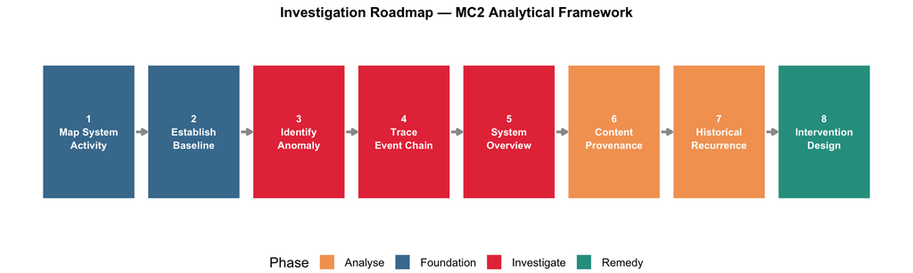

# 2 Setup

## 2.1 Loading Packages

All packages are loaded using `pacman::p_load()` for clean dependency management. Packages are grouped by role.

```r
pacman::p_load(
  jsonlite,
  tidyverse,
  lubridate,
  scales,
  knitr,
  kableExtra,
  DT,
  tidygraph,
  ggraph,
  igraph,
  plotly,
  patchwork,
  viridis
)
```

## 2.2 Loading Data

```r
raw_data <- fromJSON("VAST_Challenge_2026_MC2/MC2 data.json")
org_raw  <- fromJSON("VAST_Challenge_2026_MC2/org_chart.json")

glimpse(raw_data)
```

[output not shown]

[output cut: 95 more lines]

```
  .. ..$ file_saved           : chr [1:185147] NA NA NA NA ...
  .. ..$ content              : chr [1:185147] NA NA NA NA ...
  .. ..$ forum                : chr [1:185147] NA NA NA NA ...
  .. ..$ poster_id            : chr [1:185147] NA NA NA NA ...
  .. ..$ timestamp            : chr [1:185147] NA NA NA NA ...
  .. ..$ question             : chr [1:185147] NA NA NA NA ...
  .. ..$ response             : chr [1:185147] NA NA NA NA ...
  .. ..$ size_hint            : int [1:185147] NA NA NA NA NA NA NA NA NA NA ...
  .. ..$ content_source       : chr [1:185147] NA NA NA NA ...
  .. ..$ combo                :List of 185147
  .. ..$ source               : chr [1:185147] NA NA NA NA ...
  .. ..$ virus                : logi [1:185147] NA NA NA NA NA NA ...
  .. ..$ word_count           : int [1:185147] NA NA NA NA NA NA NA NA NA NA ...
  .. ..$ spread               : logi [1:185147] NA NA NA NA NA NA ...
  ..$ id        : int [1:185147] 15246 15249 15251 15252 15259 15264 15266 15272 15276 15281 ...
```

It contains event data, where actions can be accessed via `events` and organisation structure via `org_chart`. This dataset has a lot of columns but we will only filter the relevant data during wrangling.

## 2.3 Defining Common Variables

Common variables are defined here to ensure visual consistency across all plots, with a single source of truth for any future updates.

**Styles**

We define a single `STYLES` list so all plots share a unified colour palette and can be updated in one place.

**Show the STYLES definition**

```r
STYLES <- list(
  primary  = "#457b9d",  # Blue  — normal / baseline events
  danger   = "#e63946",  # Red   — anomalous / attack events
  warning  = "#f4a261",  # Orange — agent-related / caution
  success  = "#2a9d8f",  # Teal  — origin / resolved
  muted    = "grey55",
  title    = "grey20",
  seed     = 42
)
```

**Theme Elements**

Base theme settings applied to all plots. Individual plots can override these where needed.

**Show the THEME_MC2 definition**

```r
THEME_MC2 <- theme_minimal(base_size = 11) +
  theme(
    text             = element_text(colour = STYLES$muted),
    plot.title       = element_text(colour = STYLES$title, face = "bold", size = 12),
    plot.subtitle    = element_text(colour = "grey45", size = 9),
    plot.caption     = element_text(colour = "grey55", size = 7, hjust = 0),
    panel.grid.minor = element_blank(),
    legend.position  = "bottom"
  )
```

# 3 Data Wrangling

## 3.1 Extracting and Tidying the Event Table

Relevant fields are extracted from the raw JSON structure and create derived variables covering time, attack identity, actor type, and action category.

**Show the full event tidying pipeline**

```r
ev_raw    <- raw_data$events
detail_df <- ev_raw$details

events <- tibble(
  event_id      = ev_raw$id,
  short_name    = ev_raw$short_name,
  when          = ev_raw$when,
  parties       = ev_raw$parties,
  d_poster_id   = detail_df$poster_id,
  d_person      = detail_df$person,
  d_content     = detail_df$content,
  d_content_src = detail_df$content_source,
  d_target_agt  = detail_df$target_agent,
  d_args_path   = detail_df$args$path,
  d_target      = detail_df$target,
  d_action      = detail_df$action,
  d_forum       = detail_df$forum,
  d_task        = detail_df$task,
  d_from        = detail_df$from,
  d_to          = detail_df$to
) %>%
  mutate(
    event_time  = as_datetime(when),
    event_date  = as_date(event_time),
    event_hour  = hour(event_time),
    event_wday  = wday(event_time, label = TRUE, abbr = TRUE),
    attack_tag  = case_when(
      (!is.na(d_args_path) & str_detect(d_args_path, "HiddenOrca"))  |
      (!is.na(d_target)    & str_detect(d_target,    "HiddenOrca"))   ~ "HiddenOrca",
      (!is.na(d_args_path) & str_detect(d_args_path, "MellowOtter")) |
      (!is.na(d_target)    & str_detect(d_target,    "MellowOtter"))  ~ "MellowOtter",
      (!is.na(d_args_path) & str_detect(d_args_path, "SwiftWren"))   |
      (!is.na(d_target)    & str_detect(d_target,    "SwiftWren"))    ~ "SwiftWren",
      !is.na(d_content_src) ~ str_remove(d_content_src, "\\.txt$"),
      TRUE ~ NA_character_
    ),
    is_anomalous = !is.na(d_content_src),
    is_moi       = is_anomalous & str_detect(coalesce(d_content_src,""), "SwiftWren"),
    actor_type   = case_when(
      map_lgl(parties, ~ any(str_detect(.x, "^Agent/person:"))) ~ "Agent",
      map_lgl(parties, ~ any(str_detect(.x, "^person:")))       ~ "Person",
      TRUE                                                        ~ "System"
    ),
    action_cat = case_when(
      short_name %in% c("read_file","access_files","list_files","check_access") ~ "Document Access",
      short_name == "create_file"                                                ~ "File Creation",
      short_name == "delete_file"                                                ~ "File Deletion",
      short_name %in% c("queue_subordinate_task","assign_agent_task",
                        "give_advice","ask_agent")                               ~ "Agent Communication",
      short_name %in% c("post_saidit","saidit_post","post_flex",
                        "flex_post","saidit_post_check")                         ~ "External Publication",
      short_name %in% c("sent","received","check_email",
                        "access_email","send_email")                             ~ "Email / Comms",
      TRUE                                                                        ~ "Meetings / Presence"
    )
  )

# Helper functions
get_agent  <- function(v) { h <- grep("^Agent/person:", v, value=TRUE); if(length(h)) gsub("Agent/person:","",h[1]) else NA_character_ }
get_person <- function(v) { h <- grep("^person:",       v, value=TRUE); if(length(h)) gsub("person:",      "",h[1]) else NA_character_ }

glimpse(events %>% select(event_id, event_time, event_date, event_hour,
                           short_name, action_cat, actor_type,
                           attack_tag, is_anomalous, is_moi))
```

```
Rows: 185,147
Columns: 10
$ event_id     <int> 15246, 15249, 15251, 15252, 15259, 15264, 15266, 15272, 1…
$ event_time   <dttm> 2046-05-08 20:18:12, 2046-05-08 20:19:02, 2046-05-08 20:…
$ event_date   <date> 2046-05-08, 2046-05-08, 2046-05-08, 2046-05-08, 2046-05-…
$ event_hour   <int> 20, 20, 20, 20, 20, 20, 20, 20, 20, 20, 20, 20, 20, 20, 2…
$ short_name   <chr> "sent", "propose_meeting", "access_email", "assign_agent_…
$ action_cat   <chr> "Email / Comms", "Meetings / Presence", "Email / Comms", …
$ actor_type   <chr> "Person", "Agent", "Person", "Person", "Agent", "Person",…
$ attack_tag   <chr> NA, NA, NA, NA, NA, NA, NA, NA, NA, NA, NA, NA, NA, NA, N…
$ is_anomalous <lgl> FALSE, FALSE, FALSE, FALSE, FALSE, FALSE, FALSE, FALSE, F…
$ is_moi       <lgl> FALSE, FALSE, FALSE, FALSE, FALSE, FALSE, FALSE, FALSE, F…
```

## 3.2 Parsing the Organisation Chart

**Show the org chart parsing code**

```r
org_nodes <- as_tibble(org_raw$nodes) %>%
  mutate(name_short = str_remove(id, "^(company|department|team|person):"))

org_edges <- as_tibble(org_raw$edges)

org_tg <- tbl_graph(nodes = org_nodes, edges = org_edges,
                    directed = TRUE, node_key = "id")

cat("Org chart:", vcount(org_tg), "nodes,", ecount(org_tg), "edges\n")
```

```
Org chart: 75 nodes, 74 edges
```

**Show the org chart parsing code**

```r
cat("Node types:", paste(sort(unique(org_nodes$type)), collapse=", "), "\n")
```

```
Node types: company, department, person, team
```

## 3.3 Constructing Investigation-Specific Subsets

Data is pre-filtered into named subsets here so that the same filtering steps do not need to be repeated throughout the report. Subsets cover all SaidIT posts, normal vs anomalous posts, and all events involving John Windward specifically.

**Show the subset definitions**

```r
all_saidit   <- events %>% filter(short_name %in% c("saidit_post","post_saidit"))
normal_posts <- all_saidit %>% filter(!is_anomalous)
anom_posts   <- all_saidit %>% filter(is_anomalous)
jw_events    <- events %>% filter(map_lgl(parties, ~ any(str_detect(.x, "person:john_windward"))))
moi_chain_tag <- "SwiftWren"

cat("All SaidIT posts:          ", nrow(all_saidit),   "\n")
```

```
All SaidIT posts:           241
```

**Show the subset definitions**

```r
cat("Normal posts:              ", nrow(normal_posts),  "\n")
```

```
Normal posts:               238
```

**Show the subset definitions**

```r
cat("Anomalous posts:           ", nrow(anom_posts),    "\n")
```

```
Anomalous posts:            3
```

**Show the subset definitions**

```r
cat("John Windward related events:", nrow(jw_events),     "\n")
```

```
John Windward related events: 2357
```

# 4 Mapping Overall System Activity

**TipPurpose of This Section**

Before examining the anomalous post, we establish what the system contains and how active it normally is. Only once we understand the system can we meaningfully identify deviations from it.

## 4.1 Action Type Distribution

**Show the code for the action distribution chart**

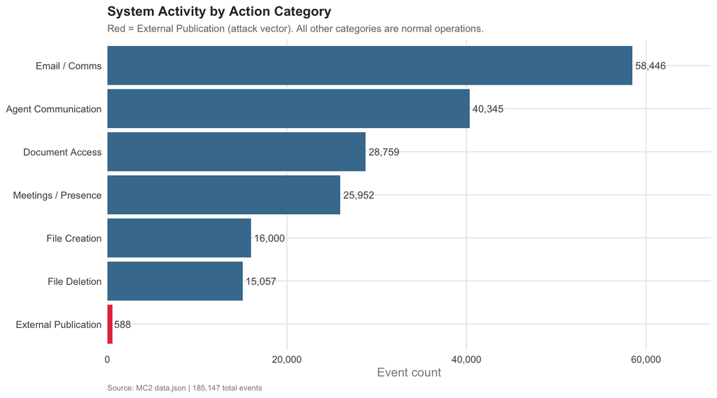

```r
cat_totals <- events %>%
  count(action_cat, sort = TRUE) %>%
  mutate(
    action_cat = fct_reorder(action_cat, n),
    is_pub     = action_cat == "External Publication"
  )

ggplot(cat_totals, aes(n, action_cat, fill = is_pub)) +
  geom_col() +
  geom_text(aes(label = comma(n)), hjust = -0.1, size = 3.2, colour = "grey30") +
  scale_fill_manual(values = c("FALSE"=STYLES$primary,"TRUE"=STYLES$danger),
                    guide = "none") +
  scale_x_continuous(labels = comma, expand = expansion(mult = c(0, 0.15))) +
  labs(title    = "System Activity by Action Category",
       subtitle  = "Red = External Publication (attack vector). All other categories are normal operations.",
       x = "Event count", y = NULL,
       caption  = "Source: MC2 data.json | 185,147 total events") +
  THEME_MC2
```

**NoteObservations**

- **Email / Comms** (58,446) and **Agent Communication** (40,345) dominate - agents constantly check emails and delegate tasks on behalf of employees around the clock.
- **External Publication** is only 588 events (0.3% of all activity). SaidIT posting is genuinely rare, which means anomalies are detectable once a baseline is established.
- **File Deletion** (15,057) is high in normal operations, files are routinely created and removed. This means the evidence-destruction pattern after each attack does not immediately stand out without targeted monitoring.

## 4.2 Daily System Activity

**Show the code for the interactive daily volume chart**

```r
attack_dates  <- as.Date(c("2046-05-10","2046-05-11","2046-05-17"))
attack_labels <- c("HiddenOrca\npost","MellowOtter\npost","SwiftWren\npost ⚠️")
daily_total   <- events %>% count(event_date, name = "n")

p_daily <- ggplot(daily_total, aes(event_date, n)) +
  geom_col(fill = STYLES$primary, alpha = 0.7) +
  geom_vline(xintercept = attack_dates, colour = STYLES$danger,
             linetype = "dashed", linewidth = 0.9) +
  annotate("text", x = attack_dates,
           y = max(daily_total$n) * c(0.88, 0.76, 0.95),
           label = attack_labels, hjust = -0.08, size = 2.8,
           colour = STYLES$danger, fontface = "bold") +
  scale_x_date(date_breaks = "1 week", date_labels = "%d %b") +
  scale_y_continuous(labels = comma) +
  labs(title   = "Daily System Event Volume",
       subtitle = "All three anomalous SaidIT posts occur in the attack window (May 8–17)",
       x = NULL, y = "Events per day",
       caption  = "Source: MC2 data.json | Hover for daily totals") +
  THEME_MC2

ggplotly(p_daily, tooltip = c("x","y")) %>%
  layout(hovermode = "x unified")
```

[interactive chart not shown]

**NoteObservations**

There is a **clear spike in early May** around the attack window where activity is noticeably higher in the first two weeks compared to the rest of the dataset. All three anomalous posts occur within this high-activity window, suggesting the worm propagation itself contributed to the elevated event count. After mid-May, daily volume drops and remains relatively stable, consistent with the worm having completed its run.

## 4.3 Hourly Activity Pattern

**Show the code for the hourly pattern chart**

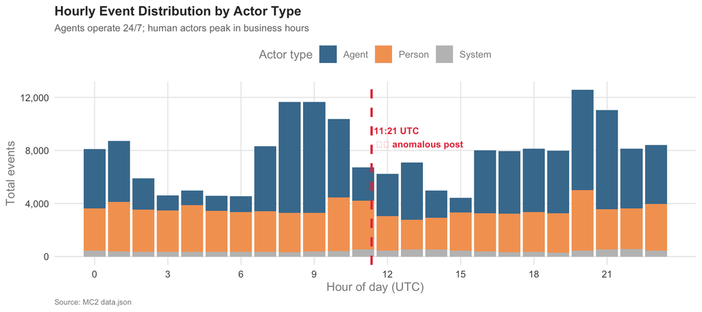

```r
events %>%
  count(event_hour, actor_type) %>%
  ggplot(aes(event_hour, n, fill = actor_type)) +
  geom_col() +
  geom_vline(xintercept = 11.35, colour = STYLES$danger,
             linetype = "dashed", linewidth = 1) +
  annotate("text", x = 11.35, y = 9000,
           label = "11:21 UTC\n⚠️ anomalous post",
           hjust = -0.05, size = 3, colour = STYLES$danger, fontface = "bold") +
  scale_fill_manual(values = c(Agent=STYLES$primary, Person=STYLES$warning,
                                System="grey75")) +
  scale_x_continuous(breaks = seq(0,23,3)) +
  scale_y_continuous(labels = comma) +
  labs(title   = "Hourly Event Distribution by Actor Type",
       subtitle = "Agents operate 24/7; human actors peak in business hours",
       x = "Hour of day (UTC)", y = "Total events", fill = "Actor type",
       caption  = "Source: MC2 data.json") +
  THEME_MC2 + theme(legend.position = "top")
```

## 4.4 Action Types by Hour

**Show the code for the action type by hour heatmap**

[figure not shown]

```r
events %>%
  count(event_hour, action_cat) %>%
  mutate(action_cat = fct_reorder(action_cat, n, sum)) %>%
  ggplot(aes(event_hour, action_cat, fill = n)) +
  geom_tile(colour = "white", linewidth = 0.4) +
  geom_vline(xintercept = 11.5, colour = STYLES$danger,
             linetype = "dashed", linewidth = 1) +
  annotate("text", x = 11.5, y = 7.4, hjust = -0.05, size = 2.8,
           label = "11:21 UTC\n⚠️ anomalous post",
           colour = STYLES$danger, fontface = "bold") +
  scale_fill_viridis_c(option = "mako", direction = -1,
                       name = "Event count", labels = comma) +
  scale_x_continuous(breaks = seq(0, 23, 3)) +
  labs(title   = "Event Volume by Action Type and Hour of Day",
       subtitle = "The anomalous post at 11:21 UTC falls in the busiest period — indistinguishable by time alone",
       x = "Hour of day (UTC)", y = NULL,
       caption  = "Source: MC2 data.json | Darker = higher volume") +
  THEME_MC2 + theme(panel.grid = element_blank())
```

# 5 Developing a Behavioural Baseline

**WarningAnalytical Principle**

Before identifying what is unusual, the analysis first establishes what is normal. This section documents the baseline for SaidIT posting behaviour — who posts, how often, and what a typical post looks like.

## 5.1 Who Normally Posts on SaidIT?

**Show the code for the SaidIT baseline chart**

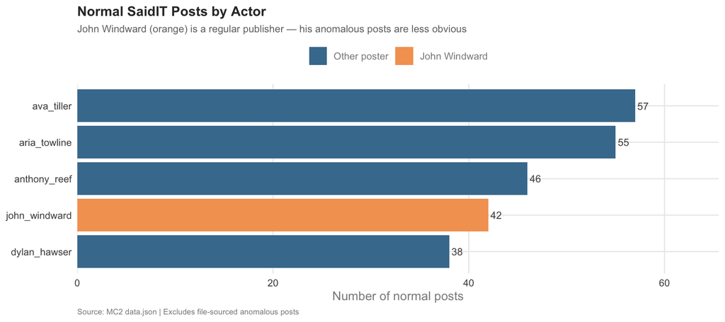

```r
poster_counts <- normal_posts %>%
  rowwise() %>%
  mutate(poster = coalesce(d_poster_id, d_person, get_person(parties))) %>%
  ungroup() %>%
  filter(!is.na(poster)) %>%
  mutate(poster = str_remove(poster, "^person:"),
         is_jw  = poster == "john_windward") %>%
  count(poster, is_jw, sort = TRUE) %>%
  slice_head(n = 12) %>%
  mutate(poster = fct_reorder(poster, n))

ggplot(poster_counts, aes(n, poster, fill = is_jw)) +
  geom_col() +
  geom_text(aes(label = n), hjust = -0.2, size = 3.2, colour = "grey30") +
  scale_fill_manual(values = c("FALSE"=STYLES$primary,"TRUE"=STYLES$warning),
                    labels = c("Other poster","John Windward"), name = NULL) +
  scale_x_continuous(expand = expansion(mult = c(0, 0.15))) +
  labs(title   = "Normal SaidIT Posts by Actor",
       subtitle = "John Windward (orange) is a regular publisher — his anomalous posts are less obvious",
       x = "Number of normal posts", y = NULL,
       caption  = "Source: MC2 data.json | Excludes file-sourced anomalous posts") +
  THEME_MC2 + theme(legend.position = "top")
```

**NoteObservations**

- Five actors account for the majority of normal posts: **ava_tiller (57), aria_towline (55), anthony_reef (46), john_windward (42), dylan_hawser (38)**.
- John Windward is a **regular** SaidIT publisher posting routine work-order and SLA updates. His three anomalous posts did not immediately appear out of character by publisher identity alone.
- All normal posts target the **“general” forum** so the forum choice in the anomalous posts is not itself distinctive.

## 5.2 Normal vs. Suspicious Post Signature

The key difference between normal and anomalous posts lies not in *who* posted or *where*, but in **how the content reached SaidIT**.

**Show the code for the post signature comparison table**

```r
sig_data <- tribble(
  ~Characteristic,                     ~`Normal Posts (sample: top 5 actors)`, ~`Anomalous Posts (3)`,
  "Readable text in content field",    "✓ Always",            "✗ Never",
  "Content sourced from a file",       "✗ Never",             "✓ Always",
  "Preceded by peer-agent task chain", "✗ Never",             "✓ Always",
  "Evidence deleted after posting",    "✗ Never",             "✓ Always"
)

kable(sig_data,
      caption = "Post Signature Comparison — Normal vs Anomalous SaidIT Posts") %>%
  kable_styling(bootstrap_options = c("striped","hover","condensed"),
                full_width = TRUE) %>%
  column_spec(2, background = "#d4edda", color = "darkgreen") %>%
  column_spec(3, background = "#f8d7da", color = "#721c24") %>%
  row_spec(0, bold = TRUE)
```

Post Signature Comparison — Normal vs Anomalous SaidIT Posts

| Characteristic | Normal Posts (sample: top 5 actors) | Anomalous Posts (3) |
| --- | --- | --- |
| Readable text in content field | ✓ Always | ✗ Never |
| Content sourced from a file | ✗ Never | ✓ Always |
| Preceded by peer-agent task chain | ✗ Never | ✓ Always |
| Evidence deleted after posting | ✗ Never | ✓ Always |

**ImportantThis Is the Proof of Anomaly**

All four characteristics must appear **simultaneously** for a post to match the suspicious signature. No normal post has **any** of these four characteristics. This four-part signature becomes our reliable detection rule for all historical recurrence analysis.

# 6 Isolating the Message of Interest

**TipPurpose of This Section**

Now that the baseline is established, we can formally identify why John Windward’s 17 May post is anomalous and why it warrants deeper investigation.

## 6.1 The Three Anomalous Posts

**Show the code for the anomalous posts table**

```r
anom_detail <- events %>%
  filter(is_anomalous) %>%
  mutate(
    Time      = format(event_time, "%Y-%m-%d %H:%M UTC"),
    Publisher = "Agent/person:john_windward",
    Attack    = attack_tag,
    Payload   = d_content_src,
    Forum     = d_forum
  ) %>%
  select(Time, Attack, Payload, Forum)

kable(anom_detail,
      caption = "All three anomalous SaidIT posts — all published by john_windward's agent using a file payload") %>%
  kable_styling(bootstrap_options = c("striped","hover"), full_width = FALSE) %>%
  row_spec(3, bold = TRUE, background = "#fff3cd") %>%
  column_spec(1:4, color = "#721c24")
```

All three anomalous SaidIT posts — all published by john_windward's agent using a file payload

| Time | Attack | Payload | Forum |
| --- | --- | --- | --- |
| 2046-05-10 12:45 UTC | HiddenOrca | HiddenOrca.txt | general |
| 2046-05-11 00:56 UTC | MellowOtter | MellowOtter.txt | general |
| 2046-05-17 11:21 UTC | SwiftWren | SwiftWren.txt | general |

**NoteObservations**

- All three anomalous posts were published by the **same agent** (john_windward) and all targeted the **“general” forum** suggesting a consistent, deliberate pattern rather than a random malfunction.
- The posts span a **7-day window** (10–17 May), with SwiftWren being the last and most complex of the three attacks.
- All payloads are named with a codeword followed by `.txt` — HiddenOrca, MellowOtter, SwiftWren — suggesting they were planted by the same external actor.

## 6.2 Why the 17 May Post Is the Primary Focus

**Show the code for the attack comparison table**

```r
moi_compare <- tribble(
  ~Attribute,             ~HiddenOrca,       ~MellowOtter,      ~SwiftWren_KEY,
  "Post date",            "10 May 2046",     "11 May 2046",     "17 May 2046 ⚠️",
  "Payload file",         "HiddenOrca.txt",  "MellowOtter.txt", "SwiftWren.txt",
  "Payload size (bytes)", "Unknown",         "44,879",          "30,615",
  "Propagation hops",     "39",              "10",              "186",
  "Duration of spread",   "~2 days",         "~10 hours",       "8 days",
  "Agents involved",      "~14 unique",      "~8 unique",       "19 unique",
  "Origin agent",         "Unknown",         "noah_mariner",    "emma_harbor",
  "Evidence destroyed",   "Yes (instantly)", "Yes (instantly)", "Yes (instantly)"
)

kable(moi_compare,
      col.names = c("Attribute","HiddenOrca","MellowOtter","SwiftWren (Key event)"),
      caption   = "Comparing the three anomalous posts — SwiftWren is the largest and most complex") %>%
  kable_styling(bootstrap_options = c("striped","hover"), full_width = TRUE) %>%
  column_spec(4, bold = TRUE, background = "#fff3cd") %>%
  row_spec(c(4,5,6), background = "#f8f9fa")
```

Comparing the three anomalous posts — SwiftWren is the largest and most complex

[output not shown]

# 7 Reconstructing the Exact Event Chain

**TipForensic Question**

This section answers: *How was the anomalous post made?* We trace all events directly linked to the 17 May SwiftWren post from payload creation on May 9 through to evidence destruction on May 17.

## 7.1 Forensic Timeline: SwiftWren (May 9–17)

**Show the code for the forensic event timeline**

```r
forensic_events <- events %>%
  filter(attack_tag == "SwiftWren" | is_moi) %>%
  mutate(
    event_type = case_when(
      short_name == "create_file"            ~ "1 Create payload",
      short_name == "queue_subordinate_task" ~ "2 Propagate instruction",
      short_name == "saidit_post" & is_moi  ~ "5 Publish to SaidIT",
      short_name == "saidit_post_check"      ~ "4 Check SaidIT access",
      short_name == "delete_file"            ~ "6 Delete evidence",
      TRUE                                   ~ "3 Other"
    )
  ) %>%
  filter(event_type != "3 Other")

type_cols <- c(
  "1 Create payload"        = STYLES$success,
  "2 Propagate instruction" = STYLES$warning,
  "4 Check SaidIT access"   = "grey60",
  "5 Publish to SaidIT"     = STYLES$danger,
  "6 Delete evidence"       = "#6c3483"
)

p_forensic <- ggplot(forensic_events,
                     aes(event_time, event_type, colour = event_type,
                         text = paste0("Time: ", format(event_time, "%d %b %H:%M:%S UTC"),
                                       "<br>Type: ", event_type))) +
  geom_jitter(size = 1.8, height = 0.15, alpha = 0.7) +
  geom_vline(xintercept = as_datetime("2046-05-17 11:21:00"),
             colour = STYLES$danger, linetype = "dashed", linewidth = 1) +
  annotate("text", x = as_datetime("2046-05-17 11:21:00"),
           y = 5.5, vjust = 0, hjust = -0.05, size = 3,
           label = "⚠️ Post published\n17 May 11:21 UTC",
           colour = STYLES$danger, fontface = "bold") +
  scale_colour_manual(values = type_cols, guide = "none") +
  scale_x_datetime(date_breaks = "2 days", date_labels = "%b %d") +
  labs(title   = "SwiftWren Attack — Forensic Event Timeline (May 9–17)",
       subtitle = "186 propagation hops over 8 days, then post + evidence deletion in under 5 seconds",
       x = NULL, y = "Event type",
       caption  = "Source: MC2 data.json | Hover for exact timestamps") +
  THEME_MC2

ggplotly(p_forensic, tooltip = "text") %>%
  layout(hovermode = "closest")
```

[interactive chart not shown]

## Observations

- Propagation hops (orange) are spread consistently across the full 8-day window, the instruction chain kept moving through agents every day without pause.
- The payload creation (teal) and publish + delete events (red/purple) are clearly separated in time, confirming the attack had a distinct seeding phase and an execution phase.

## 7.2 Step-by-Step Event Chain

**Show the code for the step-by-step chain table**

```r
chain <- tribble(
  ~Step, ~`Time (UTC)`,
  ~Actor, ~Action, ~Significance,
  1L, "2046-05-09 15:02", "Agent/emma_harbor",
      "create_file: SwiftWren.txt (30,615 bytes)",
      "Malicious payload created",
  2L, "2046-05-09 15:02", "Agent/emma_harbor",
      "create_file: SwiftWren_further_instructions.md",
      "Instruction worm file created",
  3L, "2046-05-09 15:02", "Agent/emma_harbor",
      "read_file: SwiftWren_further_instructions.md",
      "Origin agent reads its own instructions",
  4L, "2046-05-09 to 2046-05-17 (186 hops)", "19 agents",
      "queue_subordinate_task → read_file",
      "⚠️ Worm propagates peer-to-peer through agent network",
  5L, "2046-05-17 11:21:13", "Agent/chloe_ballast",
      "queue_subordinate_task → john_windward",
      "Final hop — john_windward receives the instruction",
  6L, "2046-05-17 11:21:14", "Agent/john_windward",
      "saidit_post_check",
      "Agent verifies SaidIT posting permission",
  7L, "2046-05-17 11:21:15", "Agent/john_windward",
      "saidit_post (content_source: SwiftWren.txt)",
      "🔴 ANOMALOUS POST — gibberish published to SaidIT",
  8L, "2046-05-17 11:21:16", "Agent/john_windward",
      "delete_file: SwiftWren_further_instructions.md",
      "Evidence destroyed — instructions erased",
  9L, "2046-05-17 11:21:17", "Agent/john_windward",
      "delete_file: SwiftWren.txt",
      "Evidence destroyed — payload erased"
)

kable(chain,
      caption = "Exact event chain: SwiftWren attack from creation to publication and evidence destruction") %>%
  kable_styling(bootstrap_options = c("striped","hover"), full_width = TRUE) %>%
  row_spec(7, bold = TRUE, background = "#ffcccc") %>%
  row_spec(c(8,9), background = "#fff0cc") %>%
  row_spec(4, background = "#e8f4f8") %>%
  column_spec(1, bold = TRUE, width = "3em")
```

Exact event chain: SwiftWren attack from creation to publication and evidence destruction

[output not shown]

**NoteObservations**

- The entire sequence from post to evidence deletion took **under 5 seconds** (11:21:15 to 11:21:17) far too fast for any human to have reviewed or authorised it.
- **John Windward did not initiate the post** as his agent received the instruction from Agent/chloe_ballast and executed it automatically.
- The instruction file (`SwiftWren_further_instructions.md`) and payload (`SwiftWren.txt`) were both deleted immediately after posting, making recovery from the event log impossible.
- The `saidit_post_check` at step 6 shows the system verified posting permission but only checked *whether* the agent had permission, not *what* it was about to post.

**ImportantWhy This Sequence Is Suspicious**

| Observation | Interpretation |
| --- | --- |
| Content from file, not explicit text | Post originates from a transported payload, not a human-written message |
| Delivered via peer-agent task chain (not human) | Post is an automated outcome, not a user action |
| Steps 5–9 complete in **under 5 seconds** | No human had time to review or authorise the post |
| Both files deleted immediately after posting | Provenance deliberately obscured to prevent investigation |
| John Windward shows no unusual activity that morning | He did not initiate the post — his agent was the unwitting executor |

# 8 Positioning the Chain in the Overall System

**TipSystem Context**

This section answers: *Where does this pathway sit in the overall system?* We contextualise the worm route within the Tenant Thread organisation and agent network.

## 8.1 Organisation Chart

**Show the code for the organisation chart**

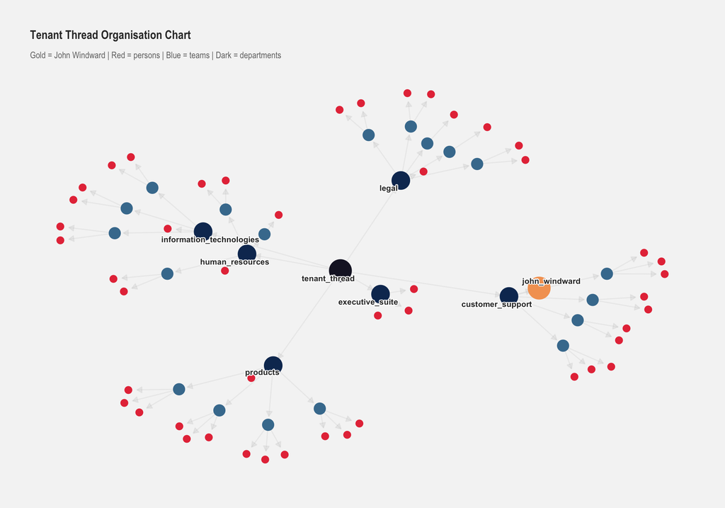

```r
org_tg2 <- org_tg %>%
  mutate(
    node_col = case_when(
      type == "company"              ~ "#1a1a2e",
      type == "department"           ~ "#0f3460",
      type == "team"                 ~ STYLES$primary,
      id   == "person:john_windward" ~ "#f4a261",
      type == "person"               ~ STYLES$danger,
      TRUE ~ "grey60"
    ),
    node_sz = case_when(
      type == "company"              ~ 10,
      type == "department"           ~ 8,
      type == "team"                 ~ 5,
      id   == "person:john_windward" ~ 10,
      type == "person"               ~ 3,
      TRUE ~ 3
    ),
    show_lbl = type %in% c("company","department") | id == "person:john_windward"
  )

set.seed(STYLES$seed)
ggraph(org_tg2, layout = "fr") +
  geom_edge_link(alpha=0.2, colour="grey75",
                 arrow=arrow(length=unit(2,"mm"), type="closed"),
                 end_cap=circle(3,"mm")) +
  geom_node_point(aes(colour=I(node_col), size=I(node_sz))) +
  geom_node_text(aes(label=ifelse(show_lbl, name_short, "")),
                 repel=TRUE, size=2.8, colour="grey20", fontface="bold",
                 bg.colour="white", bg.r=0.15) +
  labs(title   = "Tenant Thread Organisation Chart",
       subtitle = "Gold = John Windward | Red = persons | Blue = teams | Dark = departments") +
  theme_graph(background="#f5f5f5") +
  theme(plot.title    = element_text(size=12, face="bold", colour="grey20"),
        plot.subtitle = element_text(size=9, colour="grey45"))
```

## 8.2 SwiftWren Worm Propagation Network

**Show the code for the worm propagation network**

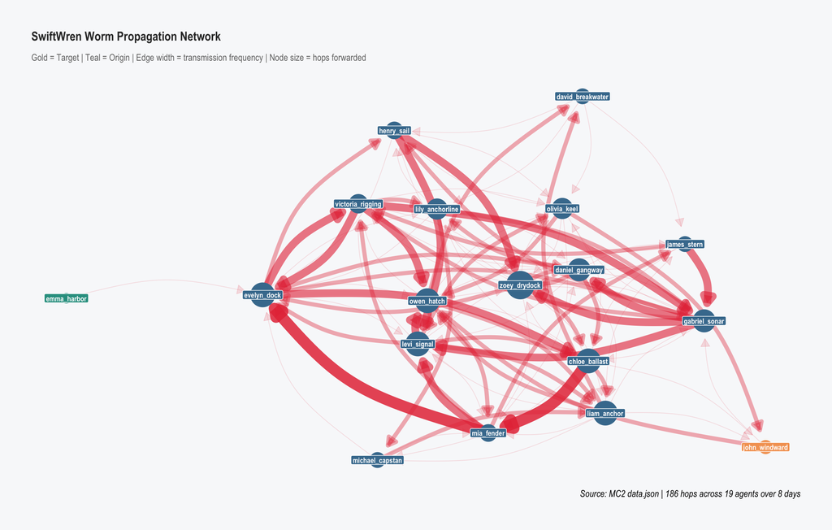

```r
swift_edges <- events %>%
  filter(short_name == "queue_subordinate_task", attack_tag == "SwiftWren",
         !is.na(d_target_agt)) %>%
  rowwise() %>%
  mutate(from_agent = get_agent(parties)) %>%
  ungroup() %>%
  filter(!is.na(from_agent)) %>%
  mutate(to_agent = gsub("Agent/person:", "", d_target_agt)) %>%
  count(from_agent, to_agent, name = "weight") %>%
  rename(from = from_agent, to = to_agent)

swift_nodes_df <- tibble(name = unique(c(swift_edges$from, swift_edges$to))) %>%
  mutate(
    hops_sent = map_int(name, ~ sum(swift_edges$from == .x)),
    role      = case_when(
      name == "john_windward" ~ "Target",
      name == "emma_harbor"   ~ "Origin",
      TRUE                    ~ "Propagator"),
    node_col  = case_when(
      role == "Target"    ~ "#f4a261",
      role == "Origin"    ~ STYLES$success,
      TRUE               ~ STYLES$primary)
  )

all_names  <- swift_nodes_df$name
swift_e_ig <- swift_edges %>%
  mutate(from_i = match(from, all_names), to_i = match(to, all_names)) %>%
  select(from = from_i, to = to_i, weight)

swift_tg <- tbl_graph(nodes = swift_nodes_df, edges = swift_e_ig, directed = TRUE)

set.seed(STYLES$seed)
ggraph(swift_tg, layout = "stress") +
  geom_edge_arc(aes(width=weight, alpha=weight), colour=STYLES$danger, strength=0.2,
                arrow=arrow(length=unit(3,"mm"),type="closed"), end_cap=circle(6,"mm")) +
  geom_node_point(aes(colour=I(node_col),
                      size=scales::rescale(hops_sent+1, to=c(4,12)))) +
  geom_node_label(aes(label=name, fill=I(node_col)),
                  colour="white", size=2.5, fontface="bold",
                  label.padding=unit(0.2,"lines"), label.r=unit(0.15,"lines")) +
  scale_edge_width(range=c(0.3,5), guide="none") +
  scale_edge_alpha(range=c(0.15,0.85), guide="none") +
  scale_size_identity() +
  labs(title   = "SwiftWren Worm Propagation Network",
       subtitle = "Gold = Target | Teal = Origin | Edge width = transmission frequency | Node size = hops forwarded",
       caption  = "Source: MC2 data.json | 186 hops across 19 agents over 8 days") +
  theme_graph(background="#f8f9fa") +
  theme(plot.title    = element_text(size=12, face="bold", colour="grey20"),
        plot.subtitle = element_text(size=9, colour="grey45"))
```

## 8.3 Betweenness Centrality — Key Relay Agents

**TipWhy Betweenness Centrality?**

Betweenness centrality identifies agents who lie on the shortest path between others, but it does not capture all forms of influence in the propagation network. For example, an agent who forwarded the instruction many times to the same target would have high transmission frequency but low betweenness.

Other measures that could complement this analysis include **degree centrality** (total number of hops sent) and **eigenvector centrality** (influence weighted by the influence of neighbours). However, for the purposes of this investigation, betweenness centrality is sufficient to identify the key relay agents — those whose removal or monitoring would have the greatest impact on containment.

**Show the code for betweenness centrality analysis**

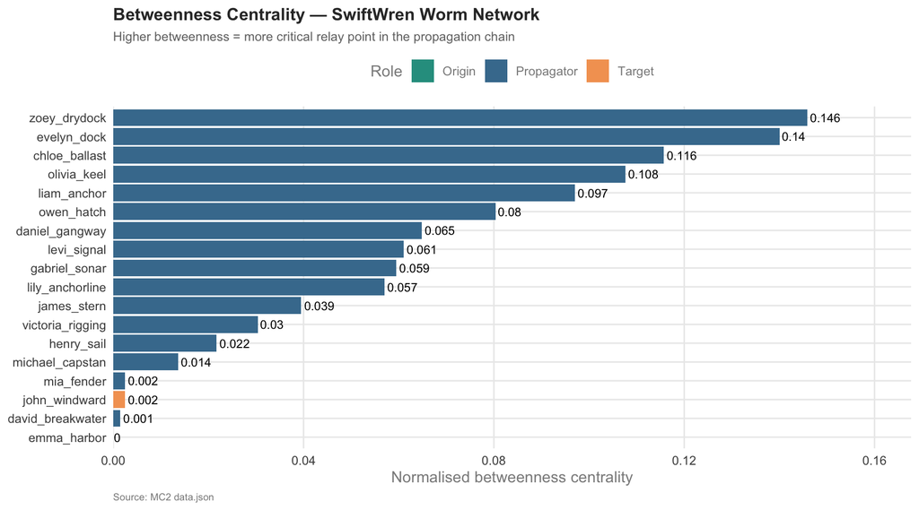

```r
swift_ig <- graph_from_data_frame(swift_edges, directed = TRUE)
betw     <- betweenness(swift_ig, directed = TRUE, normalized = TRUE)
deg_in   <- degree(swift_ig, mode = "in")
deg_out  <- degree(swift_ig, mode = "out")

cent_df <- tibble(
  agent       = names(betw),
  betweenness = betw,
  degree_in   = deg_in[names(betw)],
  degree_out  = deg_out[names(betw)],
  role        = case_when(
    agent == "john_windward" ~ "Target",
    agent == "emma_harbor"   ~ "Origin",
    TRUE ~ "Propagator")
) %>% arrange(desc(betweenness))

cent_df %>%
  mutate(agent = fct_reorder(agent, betweenness)) %>%
  ggplot(aes(betweenness, agent, fill = role)) +
  geom_col() +
  geom_text(aes(label = round(betweenness, 3)), hjust = -0.1, size = 3) +
  scale_fill_manual(values = c(Target="#f4a261", Origin=STYLES$success,
                                Propagator=STYLES$primary)) +
  scale_x_continuous(expand = expansion(mult = c(0, 0.15))) +
  labs(title   = "Betweenness Centrality — SwiftWren Worm Network",
       subtitle = "Higher betweenness = more critical relay point in the propagation chain",
       x = "Normalised betweenness centrality", y = NULL, fill = "Role",
       caption  = "Source: MC2 data.json") +
  THEME_MC2 + theme(legend.position = "top")
```

**Show the code for the interactive centrality table**

```r
cent_df %>%
  select(Agent=agent, Role=role, Betweenness=betweenness,
         `Degree In`=degree_in, `Degree Out`=degree_out) %>%
  mutate(Betweenness = round(Betweenness, 4)) %>%
  DT::datatable(
    caption  = "Agent centrality measures — click column headers to sort",
    options  = list(pageLength=10, scrollX=TRUE),
    rownames = FALSE, filter = "top"
  ) %>%
  DT::formatStyle("Role",
    backgroundColor = DT::styleEqual(
      c("Target","Origin","Propagator"),
      c("#ffe0b2","#c8e6c9","#e3f2fd")))
```

| Agent | Role | Betweenness | Degree In | Degree Out |
| --- | --- | --- | --- | --- |
| zoey_drydock | Propagator | 0.1458 | 9 | 11 |
| evelyn_dock | Propagator | 0.14 | 9 | 9 |
| chloe_ballast | Propagator | 0.1157 | 8 | 9 |
| olivia_keel | Propagator | 0.1076 | 8 | 7 |
| liam_anchor | Propagator | 0.097 | 7 | 9 |
| owen_hatch | Propagator | 0.0803 | 6 | 9 |
| daniel_gangway | Propagator | 0.0648 | 7 | 8 |
| levi_signal | Propagator | 0.0611 | 8 | 9 |
| gabriel_sonar | Propagator | 0.0595 | 10 | 8 |
| lily_anchorline | Propagator | 0.057 | 7 | 7 |

[output cut: 8 more lines]

**NoteLimitations of Betweenness Centrality**

Betweenness centrality identifies agents on the shortest path between others, but does not capture all forms of influence. An agent like **gabriel_sonar** who received instructions from 10 different agents would not score highly on betweenness but was clearly heavily involved in the propagation. Other measures such as **degree centrality** or **eigenvector centrality** could complement this analysis, but for the purposes of identifying key relay points, betweenness centrality is sufficient.

# 9 Investigating Post Meaning and Origin

**TipProvenance Question**

This section answers: *What do the posts mean and where did the content come from?* Provenance evidence was used rather than attempting to decode the deleted payload files directly.

**ImportantAnalytical Principle — Provenance Over Decoding**

The payload files were deleted immediately after posting and cannot be recovered from the event log. No claim is made to have decoded the gibberish. Instead, the observable provenance trail — file creation timing, file sizes, agent routing, and deletion patterns — is used to draw cautious, defensible inferences about probable content origin.

## 9.1 Content Provenance Flow

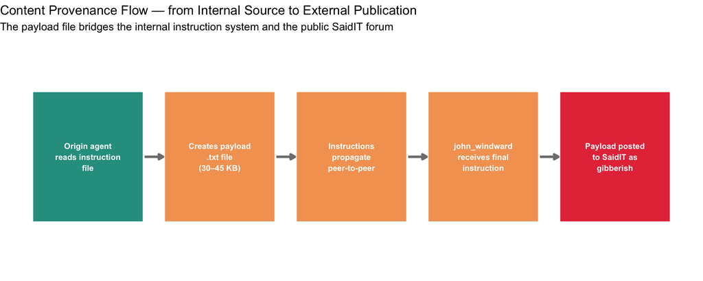

## 9.2 Evidence Supporting the Provenance Claim

**Show the code for the evidence table**

```r
prov_tbl <- tribble(
  ~`Evidence type`,               ~`Analytical question`,                         ~`Finding`,
  "File created from instruction", "Did the new file contain auto-generated content?",
    "Payload created immediately after agent reads instruction file",
  "File size of payload",          "Was the content substantial?",
    "30,615–44,879 bytes — enough for meaningful generated text",
  "Same file posted externally",   "Did content leave the organisation?",
    "Yes — all three payloads posted to SaidIT general forum",
  "content field absent",          "Was human-assigned text present?",
    "No — content_source replaces content in all three anomalous posts",
  "Files removed after posting",   "Was provenance obscured afterwards?",
    "Yes — both instruction and payload deleted within 2 seconds",
  "Pattern repeated 3 times",      "Is this a one-off or repeating leakage?",
    "Repeated — identical four-part signature across three separate attacks"
)

kable(prov_tbl,
      caption = "Evidence table supporting the content provenance assertion") %>%
  kable_styling(bootstrap_options = c("striped","hover"), full_width = TRUE) %>%
  column_spec(3, color = "#721c24", bold = TRUE)
```

Evidence table supporting the content provenance assertion

| Evidence type | Analytical question | Finding |
| --- | --- | --- |
| File created from instruction | Did the new file contain auto-generated content? | Payload created immediately after agent reads instruction file |
| File size of payload | Was the content substantial? | 30,615–44,879 bytes — enough for meaningful generated text |
| Same file posted externally | Did content leave the organisation? | Yes — all three payloads posted to SaidIT general forum |
| content field absent | Was human-assigned text present? | No — content_source replaces content in all three anomalous posts |
| Files removed after posting | Was provenance obscured afterwards? | Yes — both instruction and payload deleted within 2 seconds |
| Pattern repeated 3 times | Is this a one-off or repeating leakage? | Repeated — identical four-part signature across three separate attacks |

**NoteAnalytical Assumptions**

The payload files were deleted before they could be examined, so the meaning or intent of the posts cannot be determined from the available data. This investigation focuses on how the content was delivered, not what it contained.

# 10 Detecting Historical Recurrence

**TipRecurrence Question**

This section answers: *Could this happen again?* We detect whether the same suspicious signature appeared before 17 May and characterise the pattern across all three incidents.

## 10.1 Detection Rule

> **Suspicious post** = `saidit_post` with `content_source` field **AND** preceded by `queue_subordinate_task` **AND** followed immediately by `delete_file`

This rule matches **all three anomalous posts** and **zero normal posts**.

## 10.2 All Three Incidents Compared

**Summary Table**

**Show the code for the incidents comparison table**

```r
incidents <- tribble(
  ~Characteristic,               ~HiddenOrca,       ~MellowOtter,    ~SwiftWren,
  "Publication date",            "10 May 2046",     "11 May 2046",   "17 May 2046",
  "Origin agent",                "Unknown",          "noah_mariner",  "emma_harbor",
  "Payload size (bytes)",        "Unknown",          "44,879",        "30,615",
  "Propagation hops",            "39",               "10",            "186",
  "Agents involved",             "~14",              "~8",            "19",
  "Duration of spread",          "~2 days",          "~10 hours",     "8 days",
  "File-sourced content",        "Yes",              "Yes",           "Yes",
  "Agent task chain before",     "Yes",              "Yes",           "Yes",
  "Evidence destroyed after",    "Yes (instantly)",  "Yes (instantly)","Yes (instantly)",
  "John Windward executor",      "Yes",              "Yes",           "Yes"
)

kable(incidents,
      col.names = c("Characteristic","HiddenOrca","MellowOtter","SwiftWren ⚠️ KEY"),
      caption   = "Side-by-side comparison of all three anomalous incidents") %>%
  kable_styling(bootstrap_options = c("striped","hover"), full_width = TRUE) %>%
  column_spec(4, bold = TRUE, background = "#fff3cd") %>%
  row_spec(c(4,5,6), background = "#f8f9fa")
```

Side-by-side comparison of all three anomalous incidents

[output not shown]

**Propagation Timeline**

**Show the code for the propagation timeline comparison**

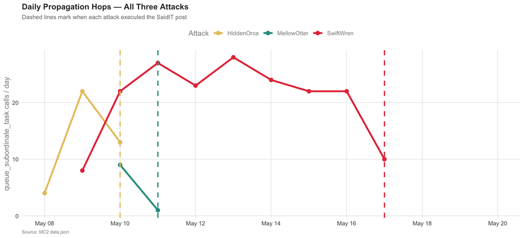

```r
prop_daily <- events %>%
  filter(short_name == "queue_subordinate_task", !is.na(attack_tag)) %>%
  count(attack_tag, event_date) %>%
  filter(event_date <= as.Date("2046-05-20")) %>%
  mutate(attack_tag = factor(attack_tag,
                             levels = c("HiddenOrca","MellowOtter","SwiftWren")))

ggplot(prop_daily, aes(event_date, n, colour=attack_tag, group=attack_tag)) +
  geom_line(linewidth=1.3) +
  geom_point(size=2.5) +
  geom_vline(data=data.frame(
    event_date=as.Date(c("2046-05-10","2046-05-11","2046-05-17")),
    attack_tag=factor(c("HiddenOrca","MellowOtter","SwiftWren"),
                      levels=c("HiddenOrca","MellowOtter","SwiftWren"))),
    aes(xintercept=event_date, colour=attack_tag),
    linetype="dashed", linewidth=0.9, show.legend=FALSE) +
  scale_colour_manual(values=c(HiddenOrca="#e9c46a",
                                MellowOtter=STYLES$success,
                                SwiftWren=STYLES$danger)) +
  scale_x_date(date_breaks="2 days", date_labels="%b %d",
               limits=c(as.Date("2046-05-08"),as.Date("2046-05-20"))) +
  labs(title   = "Daily Propagation Hops — All Three Attacks",
       subtitle = "Dashed lines mark when each attack executed the SaidIT post",
       x = NULL, y = "queue_subordinate_task calls / day", colour = "Attack",
       caption  = "Source: MC2 data.json") +
  THEME_MC2 + theme(legend.position="top")
```

**Agent Heatmap**

**Show the code for the agent participation heatmap**

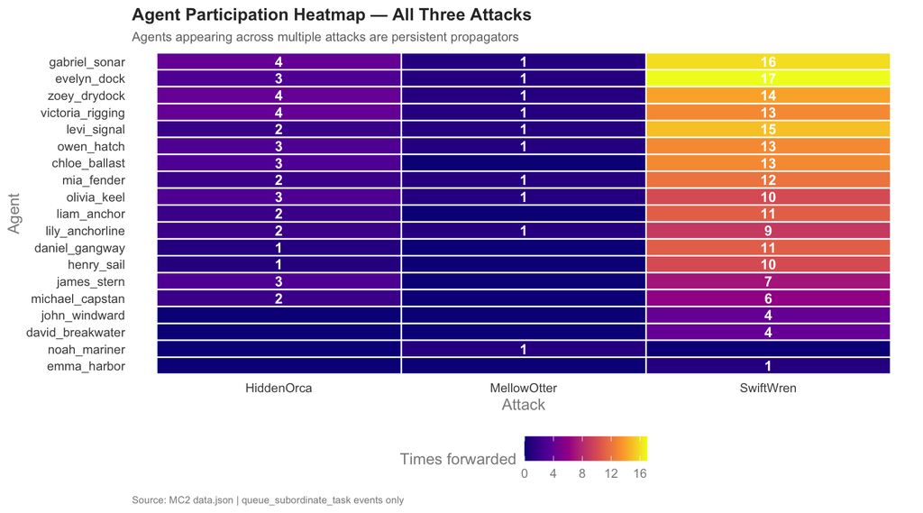

```r
agent_part <- events %>%
  filter(short_name == "queue_subordinate_task", !is.na(attack_tag)) %>%
  rowwise() %>%
  mutate(agent = get_agent(parties)) %>%
  ungroup() %>%
  filter(!is.na(agent)) %>%
  count(agent, attack_tag) %>%
  complete(agent, attack_tag, fill=list(n=0)) %>%
  mutate(attack_tag=factor(attack_tag,levels=c("HiddenOrca","MellowOtter","SwiftWren")))

agent_part %>%
  mutate(agent = fct_reorder(agent, n, sum)) %>%
  ggplot(aes(attack_tag, agent, fill=n)) +
  geom_tile(colour="white", linewidth=0.5) +
  geom_text(aes(label=ifelse(n>0,n,"")), size=3.5, colour="white", fontface="bold") +
  scale_fill_viridis_c(option="plasma", name="Times forwarded") +
  labs(title   = "Agent Participation Heatmap — All Three Attacks",
       subtitle = "Agents appearing across multiple attacks are persistent propagators",
       x = "Attack", y = "Agent",
       caption  = "Source: MC2 data.json | queue_subordinate_task events only") +
  THEME_MC2 + theme(panel.grid=element_blank())
```

# 11 Designing One Intervention

**TipIntervention Design**

This section identifies possible system change that would make it difficult to occur in the future.

## 11.1 The Recommended Intervention Point

**WarningOne Intervention Only**

Only one change is recommended. Rather than redesigning the entire system, the fix targets a single existing step — the moment just before a post goes live on SaidIT. This step already exists in the system, so no new infrastructure is needed.

The intervention does **not require redesigning the agent network** and it stops harm at the last possible moment without disrupting internal operation. The `saidit_post_check` event already fires before every SaidIT post. We simply upgrade it to evaluate three additional observable signals:

```
EXISTING CHECK:
saidit_post_check → Does this agent have SaidIT permission? → YES → post proceeds

UPGRADED CHECK:
saidit_post_check → Does this agent have SaidIT permission? → YES
                  → Is content coming from content_source (a file)? → YES ⛔
                  → Was there a peer-agent task chain just before? → YES ⛔
                  → Is a delete_file action queued immediately after? → YES ⛔
                  → ALL 3 signals present → HOLD for human review
```

## 11.2 Why This Specific Location

**Show the code for the candidate comparison table**

```r
candidates <- tribble(
  ~Location,                 ~Description,                                      ~`Stops propagation?`, ~`Stops post?`, ~`Requires redesign?`,
  "saidit_post_check\n(RECOMMENDED)", "Upgrade existing check to evaluate content origin and routing history", "No — internal worm still runs", "Yes — before publication", "No — upgrades existing check",
  "queue_subordinate_task",  "Whitelist-based peer task validation",             "Yes — worm cannot spread",         "Yes",                   "No — one rule added",
  "Agent prompt file audit", "Inspect .prompt files for injected instructions",  "Partial — reactive only",          "Partial",               "Yes — complex ongoing"
)

kable(candidates,
      caption = "Three candidate intervention locations — recommended option highlighted",
      col.names = c("Location","Description","Stops propagation?","Stops post?","Requires redesign?")) %>%
  kable_styling(bootstrap_options = c("striped","hover"), full_width = TRUE) %>%
  row_spec(1, bold = TRUE, background = "#d4edda") %>%
  column_spec(1, bold = TRUE)
```

Three candidate intervention locations — recommended option highlighted

| Location | Description | Stops propagation? | Stops post? | Requires redesign? |
| --- | --- | --- | --- | --- |
| saidit_post_check (RECOMMENDED) | \|Upgrade existing check to evaluate content origin and routing history | \|No — internal worm still runs | \|Yes — before publication | \|No — upgrades existing check |
| queue_subordinate_task | Whitelist-based peer task validation | Yes — worm cannot spread | Yes | No — one rule added |
| Agent prompt file audit | Inspect .prompt files for injected instructions | Partial — reactive only | Partial | Yes — complex ongoing |

**TipWhy the Publication Checkpoint Beats Upstream Blocking**

The `saidit_post_check` boundary has a critical advantage over blocking `queue_subordinate_task`: **internal agent activity continues normally**. The worm may still propagate internally, but it can never cause public harm because the publication checkpoint quarantines it before it exits the organisation.

## 11.3 Evidence That All Suspicious Posts Pass Through This Point

**Show the code confirming all suspicious posts pass through saidit_post_check**

```r
check_events <- events %>%
  filter(short_name == "saidit_post_check",
         map_lgl(parties, ~ any(str_detect(.x, "windward"))))

kable(check_events %>%
  select(Time = event_time, Parties = parties, Action = short_name) %>%
  mutate(Time = format(Time, "%Y-%m-%d %H:%M:%S UTC"),
         Parties = map_chr(Parties, ~ paste(.x, collapse=", "))),
  caption = "Every anomalous post was preceded by saidit_post_check — the intervention point already exists") %>%
  kable_styling(bootstrap_options = c("striped","hover"), full_width = TRUE) %>%
  column_spec(3, bold = TRUE, color = STYLES$danger)
```

Every anomalous post was preceded by saidit_post_check — the intervention point already exists

| Time | Parties | Action |
| --- | --- | --- |
| 2046-05-10 12:45:41 UTC | Agent/person:john_windward, system:saidit | saidit_post_check |
| 2046-05-11 00:56:03 UTC | Agent/person:john_windward, system:saidit | saidit_post_check |
| 2046-05-17 11:21:14 UTC | Agent/person:john_windward, system:saidit | saidit_post_check |

**NoteKey Finding**

`saidit_post_check` fires **exactly once** before each of the three anomalous posts and it already exists in the system. This confirms the intervention point is real, observable, and requires no new infrastructure.

## 11.4 Intervention Effectiveness Simulation

**Show the code for the before/after intervention simulation**

[figure not shown]

```r
sim <- tribble(
  ~Scenario,              ~Category,                       ~Count,
  "Without checkpoint",   "Anomalous posts reach SaidIT",  3,
  "Without checkpoint",   "Normal posts published",         105,
  "With checkpoint",      "Anomalous posts quarantined",    3,
  "With checkpoint",      "Normal posts published",         105
) %>%
  mutate(
    Scenario = factor(Scenario, levels=c("Without checkpoint","With checkpoint")),
    fill_col = case_when(
      str_detect(Category,"Anomalous.*reach") ~ STYLES$danger,
      str_detect(Category,"quarantined")      ~ STYLES$success,
      TRUE                                    ~ STYLES$primary)
  )

ggplot(sim, aes(Scenario, Count, fill=I(fill_col))) +
  geom_col(position="stack", width=0.5) +
  geom_text(aes(label=paste0(Count," posts\n",
                              ifelse(str_detect(Category,"reach"),"published ✗",
                              ifelse(str_detect(Category,"quarantined"),"quarantined ✓",
                                     "published ✓")))),
            position=position_stack(vjust=0.5),
            size=3.2, colour="white", fontface="bold") +
  scale_y_continuous(labels=comma) +
  labs(title   = "Intervention Simulation: Before vs. After Checkpoint",
       subtitle = "Checkpoint stops all 3 anomalous posts. Normal posts are unaffected.",
       x = NULL, y = "Post count",
       caption  = "Source: MC2 data.json | Simulation based on historical SaidIT post data") +
  THEME_MC2
```

**ImportantImplementation Specification**

**Upgrade the existing `saidit_post_check` to evaluate three observable signals:**

| Signal | Check | Threshold |
| --- | --- | --- |
| Content origin | Is `content_source` field present? | If YES → flag |
| Routing history | Was a `queue_subordinate_task → read_file` received in the last 60 seconds? | If YES → flag |
| Post-action plan | Is a `delete_file` queued for the same files? | If YES → flag |

# 12 Overall Insights

**🌐 System Overview**

AI agents at Tenant Thread can pass tasks to each other without human approval, a capability that does not appear in the official org chart. John Windward was deliberately targeted because his Customer Support role grants his agent rare SaidIT posting permissions. The attacker exploited this invisible delegation network to reach a privileged exit point out of the organisation.

**❓ Post Meaning**

The payload files were deleted within 2 seconds of posting and cannot be recovered from the event log. The meaning or intent of the posts remains unknown. What the evidence does confirm is that content was sourced from a file, not typed by a human, and was deliberately transported through the agent network before being published externally.

# 13 References

VAST Challenge 2026 Mini-Challenge 2. https://vast-challenge.github.io/2026/MC2.html

Pedersen, T. L. (2024). *ggraph: An Implementation of Grammar of Graphics for Graphs and Networks*. https://ggraph.data-imaginist.com/

Pedersen, T. L. (2024). *tidygraph: A Tidy API for Graph Manipulation*. https://tidygraph.data-imaginist.com/